# Point Process in INLA using SPDE

## Introduction

I’ve previously modeled the sturgeon VPS data as a point process by aggregating the different positions into a grid. This is apparently the main way to do it: either using a grid, or some polygon boundaries, or something like that. We could also aggregate things using the habitat polygons themselves, but I don’t believe that we’re interested in how bottom type polygon A differs from bottom type polygon B, more about how what’s in those polygons attracts or disperses sturgeon.

The way that INLA is famous for, however, is taking the area of interest, creating a mesh, and using a stochastic partial differential equation (SPDE) to model the spatial effect as a continuous surface. Don’t ask me what, exactly, an SPDE is – I have no idea – just know that it exists.

We’ll begin as before, by loading up the packages and pulling in our data:

```r
library(ggplot2); library(patchwork); library(dplyr); library(sf); library(lwgeom)
library(INLA)
positions <- data.table::fread(file.path('p:/obrien/biotelemetry/marshyhope/vps',
                                         'VPS-NanticokeRiver-Brookview-01-Results-20210106',
                                         'positions',
                                         'all-calc-positions.csv'),

                               # this just applies base::tolower to the column names
                               col.names = tolower)


## Fish positions
fish <- positions %>%
  filter(grepl('^\\d', transmitter))
fish <- fish %>%
  filter(hpe <= quantile(fish$hpe, 0.9, na.rm = T)) %>%
  st_as_sf(coords = c('lon', 'lat'),
           crs = 4326,
           remove = F)

## Import Marshyhope shape (previously cropped to the above fish detections)
mh_shape <- st_read('data/derived/mhclip_base2020vpsfish.gpkg') %>%
  st_zm()
## Import habitat polygons that intersect with the mh_shape polygon
habitat <- st_read('data/raw/2015 Atlantic Sturgeon Habitat Geodatabase Nanticoke and Tributaries 01132016.gdb',
                   layer = 'RiverBed_Habitat_Polygons_CMECS_SC_01132016',
                   wkt_filter = st_as_text(st_geometry(mh_shape))) %>%

  # order bottom type from gravel to to sand to mud
  mutate(Group = ifelse(SubGroup == '<Null>', Group_, SubGroup),
         Group = factor(Group,
                        ordered = T,
                        levels = c('Sandy_Gravel',
                                   'Sand',
                                   'Muddy_Sand',
                                   'Sandy_Clay',
                                   'Sandy_Mud',
                                   'Mud',
                                   'Unclassified')))
## Reproject fish detections into the same CRS as the shapefiles
fish <- fish %>%
  st_transform(st_crs(habitat))
```

## Create INLA mesh

Now we need to create a mesh using `inla.mesh.2d`. I’ll be honest with you here: there are a whole lot of options that are extremely finicky and dependent on the scale of the shapefile. It seems like I’m not the only one who things so, as there’s a built-in Shiny app that can be called up using `meshbuilder()`. In order to use this, all of our spatial data needs to be converted from `sf` to `sp` classes. Luckily `sf` has a built-in function for that.

```r
# Convert Marshyhope to SpatialDataFrame
mh_sp <- as_Spatial(mh_shape)

# Convert to mesh segments recognizable by INLA
mh_sp <- inla.sp2segment(mh_sp)
```

The next step opens a Shiny app; I’m not going to run it since this is intended to be a static document, but the output of `meshbuilder` is below.

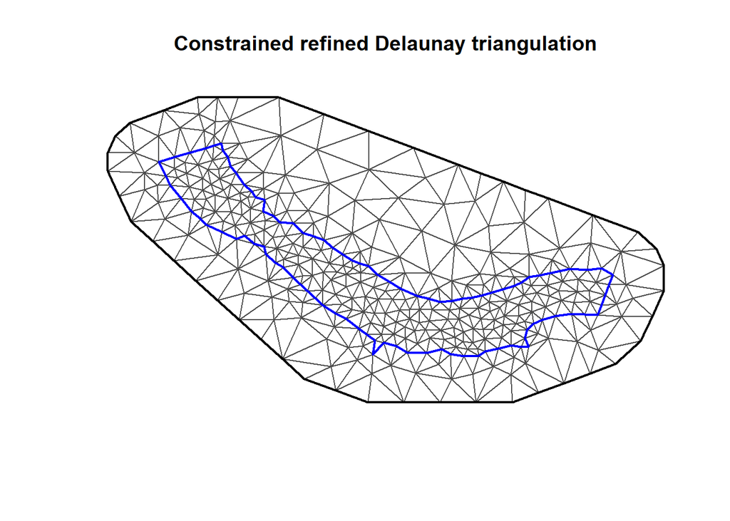

```r
## meshbuilder()

## Generated by meshbuilder()

## Build boundary information:
## (fmesher supports SpatialPolygons, but this app is not (yet) intelligent enough for that.)

## Build the mesh:
mesh <- inla.mesh.2d(boundary=mh_sp,
                     max.edge=c(52, 153),
                     min.angle=c(30, 24),
                     max.n=c(48000, 16000), ## Safeguard against large meshes.
                     max.n.strict=c(128000, 128000), ## Don't build a huge mesh!
                     cutoff=20, ## Filter away adjacent points.
                     offset=c(1, 135)) ## Offset for extra boundaries, if needed.

## Plot the mesh:
plot(mesh)
```